# Pilot Study 2 LC-MS Data

Generate the table:

```r
exudate_evidence_summary <-
  exudate_soil_abundance_candidates %>%
  count(
    evidence_tier
  )

exudate_evidence_summary
```

```
##                    evidence_tier    n
## 1         Tier 1: FDR + >=2-fold    1
## 2 Tier 3: exploratory + >=2-fold  159
## 3      Tier 4: large effect only  215
## 4           Tier 5: low priority 1011
```

Plot:

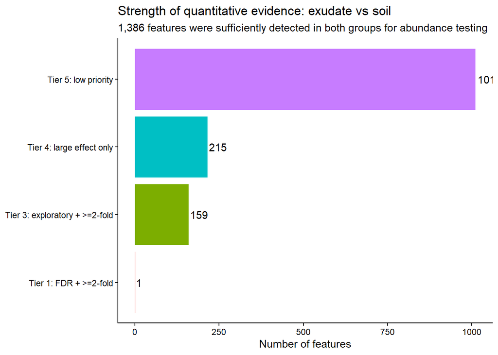

```r
exudate_evidence_plot <- ggplot(
  exudate_evidence_summary,
  aes(
    x = reorder(
      evidence_tier,
      n
    ),
    y = n,
    fill = evidence_tier
  )
) +

  geom_col() +

  coord_flip() +

  geom_text(
    aes(label = n),
    hjust = -0.1
  ) +

  labs(
    title =
      "Strength of quantitative evidence: exudate vs soil",
    subtitle =
      "1,386 features were sufficiently detected in both groups for abundance testing",
    x = NULL,
    y = "Number of features"
  ) +

  theme_classic() +

  theme(
    legend.position = "none"
  )

exudate_evidence_plot
```

138. Fungal-age summary figure

Your current numbers are:

No strong classification 1697 New-vs-control only 649 Old-vs-new differential 262 Age-stable fungal effect 14 Old-vs-control only 6

Use your actual object:

```r
fungal_age_summary
```

```
##                   fungal_age_category    n
## 1 No strong fungal-age classification 1697
## 2               New-associated effect  649
## 3         Age-sensitive fungal effect  262
## 4            Age-stable fungal effect   14
## 5               Old-associated effect    6
```

Plot:

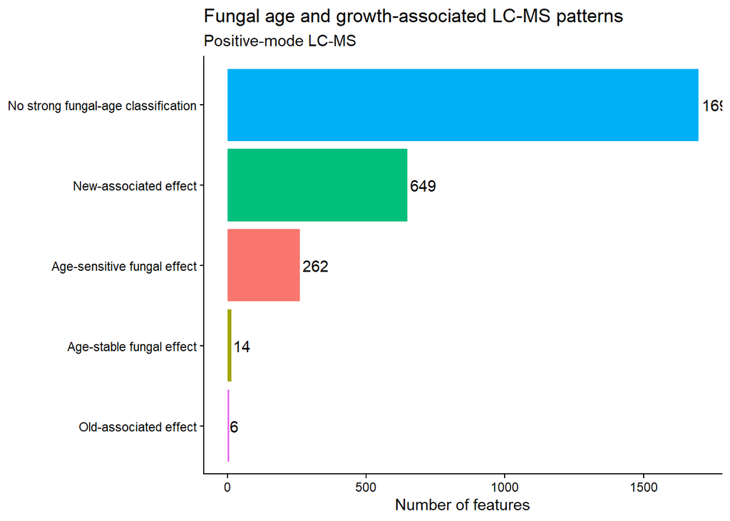

```r
fungal_age_summary_plot <- ggplot(
  fungal_age_summary,
  aes(
    x = reorder(
      fungal_age_category,
      n
    ),
    y = n,
    fill = fungal_age_category
  )
) +

  geom_col() +

  coord_flip() +

  geom_text(
    aes(label = n),
    hjust = -0.1
  ) +

  labs(
    title =
      "Fungal age and growth-associated LC-MS patterns",
    subtitle =
      "Positive-mode LC-MS",
    x = NULL,
    y = "Number of features"
  ) +

  theme_classic() +

  theme(
    legend.position = "none"
  )

fungal_age_summary_plot
```

139. Fungal-age heatmap

You already generated this. Save it explicitly when you rerun the heatmap:

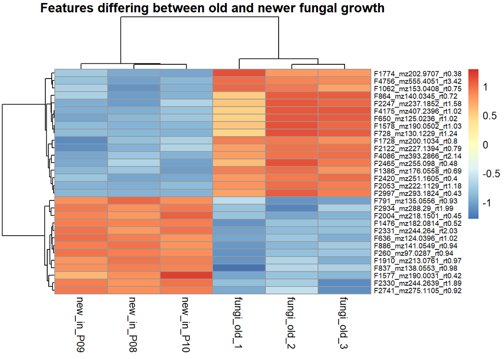

```r
png(
  "PI_figure_fungal_age_heatmap.png",
  width = 2200,
  height = 1600,
  res = 200
)

pheatmap(
  fungal_age_heatmap,
  scale = "row",
  clustering_distance_rows =
    "euclidean",
  clustering_distance_cols =
    "euclidean",
  clustering_method =
    "complete",
  show_rownames = TRUE,
  show_colnames = TRUE,
  fontsize_row = 7,
  main =
    "Features differing between old and newer fungal growth"
)
```

```r
dev.off()
```

140. Fungal top-feature boxplots

Your top fungal-age plot is useful because the heatmap only shows relative differences.

Save the boxplot:

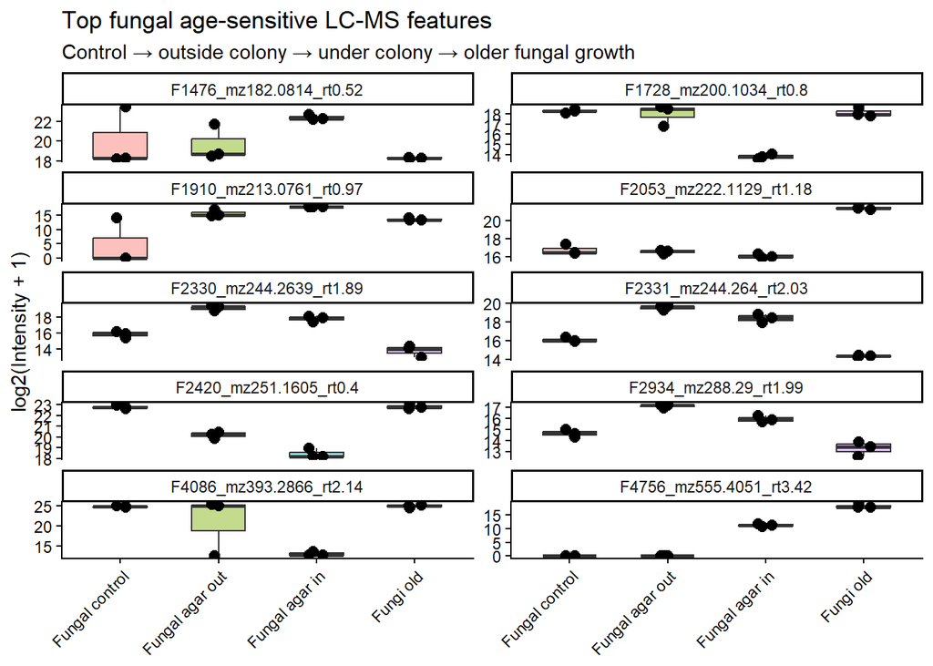

```r
fungal_age_boxplot <- ggplot(
  top_fungal_plot_data,
  aes(
    x = group,
    y = log2_intensity,
    fill = group
  )
) +

  geom_boxplot(
    width = 0.55,
    outlier.shape = NA,
    alpha = 0.45
  ) +

  geom_jitter(
    width = 0.08,
    size = 2.5
  ) +

  facet_wrap(
    ~ feature_name,
    scales = "free_y",
    ncol = 2
  ) +

  labs(
    title =
      "Top fungal age-sensitive LC-MS features",

    subtitle =
      "Control → outside colony → under colony → older fungal growth",

    x = NULL,

    y =
      "log2(Intensity + 1)"
  ) +

  theme_classic() +

  theme(
    legend.position = "none",

    axis.text.x =
      element_text(
        angle = 45,
        hjust = 1
      )
  )

fungal_age_boxplot
```

141. PCA plots to save for Laura

You already have these objects, so don’t rerun the entire PCA.

Save the broad PCA:

```r
ggsave(
  "PI_figure_global_PCA.png",
  broad_pca_plot,
  width = 9,
  height = 7,
  dpi = 300
)
```

Exudate vs soil:

```r
ggsave(
  "PI_figure_exudate_soil_PCA.png",
  quantitative_pca_results$
    Exudate_vs_Soil$plot,
  width = 8,
  height = 6,
  dpi = 300
)
```

Leaf vs root:

```r
ggsave(
  "PI_figure_leaf_root_PCA.png",
  quantitative_pca_results$
    Leaf_vs_Root$plot,
  width = 8,
  height = 6,
  dpi = 300
)
```

Fungal in vs control:

```r
ggsave(
  "PI_figure_fungal_in_control_PCA.png",
  quantitative_pca_results$
    Fungal_in_vs_control$plot,
  width = 8,
  height = 6,
  dpi = 300
)
```

Old vs new fungus:

```r
ggsave(
  "PI_figure_fungal_old_new_PCA.png",
  quantitative_pca_results$
    Fungi_old_vs_Fungal_in$plot,
  width = 8,
  height = 6,
  dpi = 300
)
```

142. Create one master PI summary table

```r
PI_summary_table <- tibble(

  result = c(

    "Raw MS-DIAL features",

    "Features after positive-mode filtering",

    "Plant-associated features",

    "Fungus-associated features",

    "Features shared between plant and fungus",

    "Strict root-exudate-fungus candidates",

    "Exudate-associated detection features",

    "Exudate-soil features quantifiable in both",

    "Exudate-soil Tier 1 abundance candidates",

    "Old-vs-new fungal differential features",

    "Age-stable fungal-associated features"
  ),

  n = c(

    nrow(feature_table),

    nrow(feature_qc),

    sum(
      cross_compartment_presence$
        plant_present,
      na.rm = TRUE
    ),

    sum(
      cross_compartment_presence$
        fungus_present,
      na.rm = TRUE
    ),

    sum(
      cross_compartment_presence$
        plant_and_fungus,
      na.rm = TRUE
    ),

    nrow(
      root_exudate_fungal_not_controls
    ),

    129,

    1386,

    sum(
      exudate_soil_abundance_candidates$
        evidence_tier ==
        "Tier 1: FDR + >=2-fold"
    ),

    sum(
      fungal_age_master$
        fungal_age_category ==
        "Age-sensitive fungal effect",
      na.rm = TRUE
    ),

    sum(
      fungal_age_master$
        fungal_age_category ==
        "Age-stable fungal effect",
      na.rm = TRUE
    )
  )
)

PI_summary_table
```

```
## # A tibble: 11 × 2
##    result                                         n
##    <chr>                                      <dbl>
##  1 Raw MS-DIAL features                        5169
##  2 Features after positive-mode filtering      4144
##  3 Plant-associated features                   3211
##  4 Fungus-associated features                  3037
##  5 Features shared between plant and fungus    2124
##  6 Strict root-exudate-fungus candidates          4
##  7 Exudate-associated detection features        129
##  8 Exudate-soil features quantifiable in both  1386
##  9 Exudate-soil Tier 1 abundance candidates       1
## 10 Old-vs-new fungal differential features      262
## 11 Age-stable fungal-associated features         14
```

I would not hard-code 129 and 1386 long term, though. For a reproducible final notebook, replace them with calculations:

```r
PI_summary_table <- tibble(

  result = c(
    "Raw MS-DIAL features",
    "Features after positive-mode filtering",
    "Plant-associated features",
    "Fungus-associated features",
    "Plant + fungus shared features",
    "Strict root-exudate-fungus candidates",
    "Exudate-associated detection features",
    "Exudate-soil quantifiable features",
    "Exudate-soil Tier 1 candidates",
    "Old-vs-new fungal differential features",
    "Age-stable fungal effects"
  ),

  n = c(

    nrow(feature_table),

    nrow(feature_qc),

    sum(
      cross_compartment_presence$plant_present,
      na.rm = TRUE
    ),

    sum(
      cross_compartment_presence$fungus_present,
      na.rm = TRUE
    ),

    sum(
      cross_compartment_presence$plant_and_fungus,
      na.rm = TRUE
    ),

    nrow(
      root_exudate_fungal_not_controls
    ),

    sum(
      prepared_comparisons$
        Exudate_vs_Soil$
        detection_table$
        detection_category ==
        "Exudate-associated detection",
      na.rm = TRUE
    ),

    nrow(
      prepared_comparisons$
        Exudate_vs_Soil$
        abundance_features
    ),

    sum(
      exudate_soil_abundance_candidates$
        evidence_tier ==
        "Tier 1: FDR + >=2-fold",
      na.rm = TRUE
    ),

    sum(
      fungal_age_master$
        fungal_age_category ==
        "Age-sensitive fungal effect",
      na.rm = TRUE
    ),

    sum(
      fungal_age_master$
        fungal_age_category ==
        "Age-stable fungal effect",
      na.rm = TRUE
    )
  )
)

PI_summary_table
```

```
## # A tibble: 11 × 2
##    result                                      n
##    <chr>                                   <int>
##  1 Raw MS-DIAL features                     5169
##  2 Features after positive-mode filtering   4144
##  3 Plant-associated features                3211
##  4 Fungus-associated features               3037
##  5 Plant + fungus shared features           2124
##  6 Strict root-exudate-fungus candidates       4
##  7 Exudate-associated detection features     129
##  8 Exudate-soil quantifiable features       1386
##  9 Exudate-soil Tier 1 candidates              1
## 10 Old-vs-new fungal differential features   262
## 11 Age-stable fungal effects                  14
```

Save:

```r
write.csv(
  PI_summary_table,
  "PI_positive_mode_results_summary.csv",
  row.names = FALSE
)
```

143. Save all the new PI tables

```r
write.csv(
  compartment_feature_counts,
  "PI_feature_counts_by_compartment.csv",
  row.names = FALSE
)

write.csv(
  plant_fungal_overlap_summary,
  "PI_plant_fungal_overlap_summary.csv",
  row.names = FALSE
)

write.csv(
  plant_fungal_partition_long,
  "PI_plant_fungal_partition.csv",
  row.names = FALSE
)

write.csv(
  pairwise_overlap_matrix,
  "PI_pairwise_feature_overlap_counts.csv"
)

write.csv(
  pairwise_percent_overlap,
  "PI_pairwise_percent_overlap.csv"
)

write.csv(
  plant_pattern_detailed,
  "PI_plant_detection_patterns.csv",
  row.names = FALSE
)

write.csv(
  fungal_pattern_detailed,
  "PI_fungal_detection_patterns.csv",
  row.names = FALSE
)

write.csv(
  strict_cross_system_candidates,
  "PI_strict_cross_system_candidates.csv",
  row.names = FALSE
)
```